# Data Science I, Workshop I: Predicting interest rates at the Lending Club

Group 5

12/10/2021

# 1 Load and prepare the data

We start by loading the data to R in a dataframe.

```r
lc_raw <- read_csv("LendingClub Data.csv",  skip=1) %>%  #since the first row is a title we want to skip it.
  clean_names() # use janitor::clean_names()
```

# 2 ICE the data: Inspect, Clean, Explore

```r
lc_clean<- lc_raw %>%
  dplyr::select(-x20:-x80) %>% #delete empty columns
  filter(!is.na(int_rate)) %>%   #delete empty rows
  mutate(
    issue_d = mdy(issue_d),  # lubridate::mdy() to fix date format
    term = factor(term_months),     # turn 'term' into a categorical variable
    delinq_2yrs = factor(delinq_2yrs) # turn 'delinq_2yrs' into a categorical variable
  ) %>%
  dplyr::select(-emp_title,-installment, -term_months, everything()) #move some not-so-important variables to the end.
```

The data is now in a clean format stored in the dataframe “lc_clean.”

## 2.1 Q1 Exploratory data analysis and visualisation

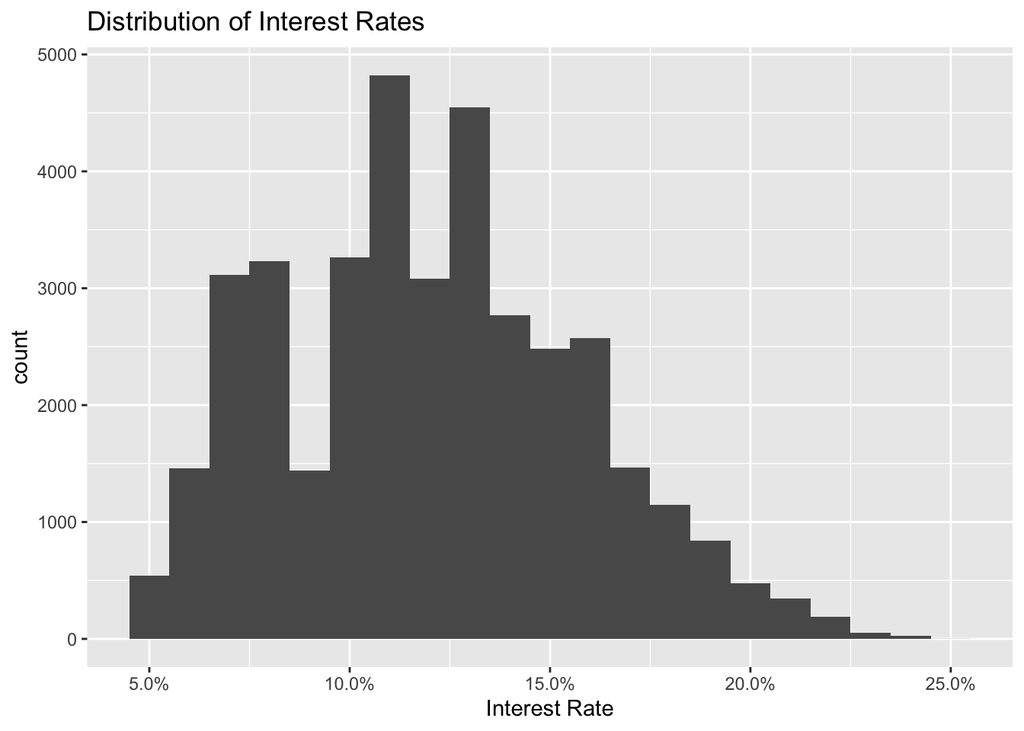

```r
# Build a histogram of interest rates.
ggplot(lc_clean, aes(x=int_rate))+
  geom_histogram(binwidth=0.01)+
  scale_x_continuous(labels = scales::percent) +
  labs(x="Interest Rate", title = "Distribution of Interest Rates")
```

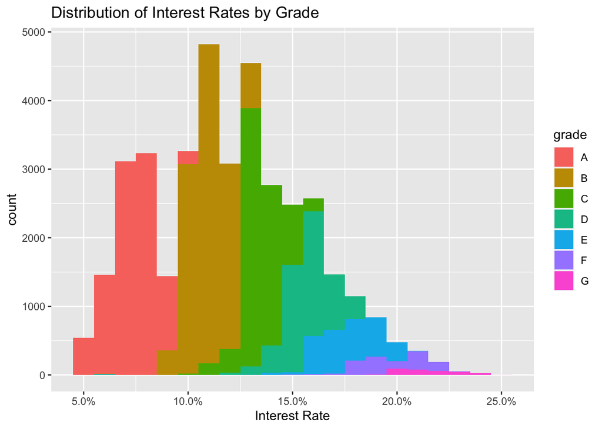

```r
# Build a histogram of interest rates but use different color for loans of different grades
ggplot(lc_clean, aes(x=int_rate, fill=grade))+
  geom_histogram(binwidth=0.01)+scale_x_continuous(labels = scales::percent)+
  labs(x="Interest Rate", title = "Distribution of Interest Rates by Grade")
```

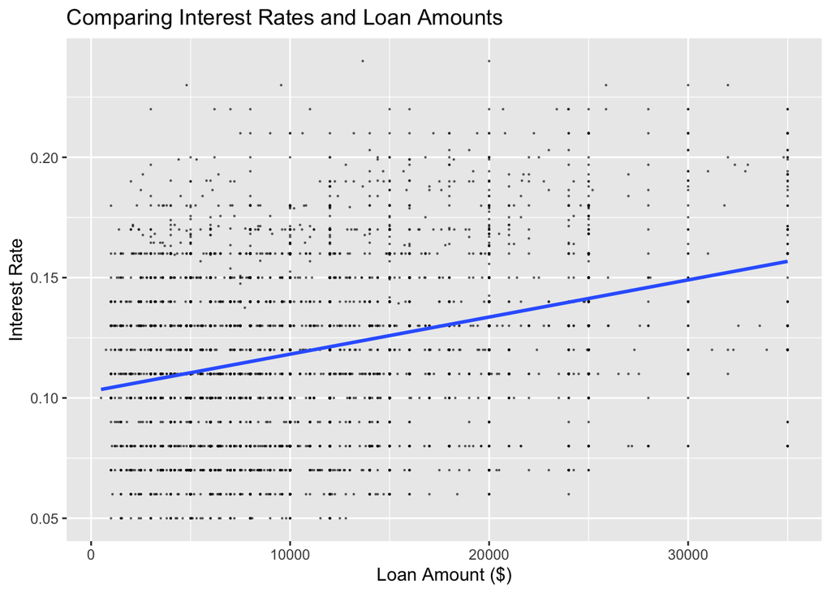

```r
# Produce a scatter plot of loan amount against interest rate and add visually the line of best fit
ggplot(lc_clean[seq(1, nrow(lc_clean), 10), ] , aes(y=int_rate, x=loan_amnt)) +
  geom_point(size=0.1, alpha=0.5)+
  geom_smooth(method="lm", se=0) +
  labs(y="Interest Rate", x="Loan Amount ($)", title = "Comparing Interest Rates and Loan Amounts")
```

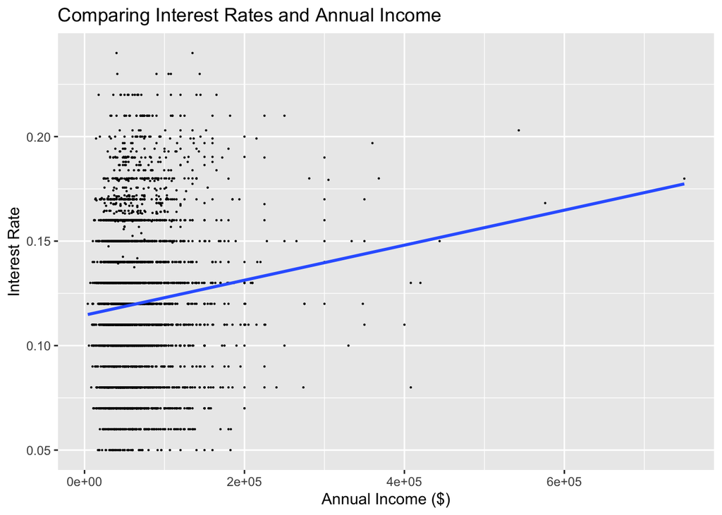

```r
# Produce a scatter plot of annual income against interest rate and add visually the line of best fit
ggplot(lc_clean[seq(1, nrow(lc_clean), 10), ] , aes(y=int_rate, x=annual_inc)) +
  geom_point(size=0.1)+
  geom_smooth(method="lm", se=0) +
  labs(y="Interest Rate", x="Annual Income ($)", title="Comparing Interest Rates and Annual Income")
```

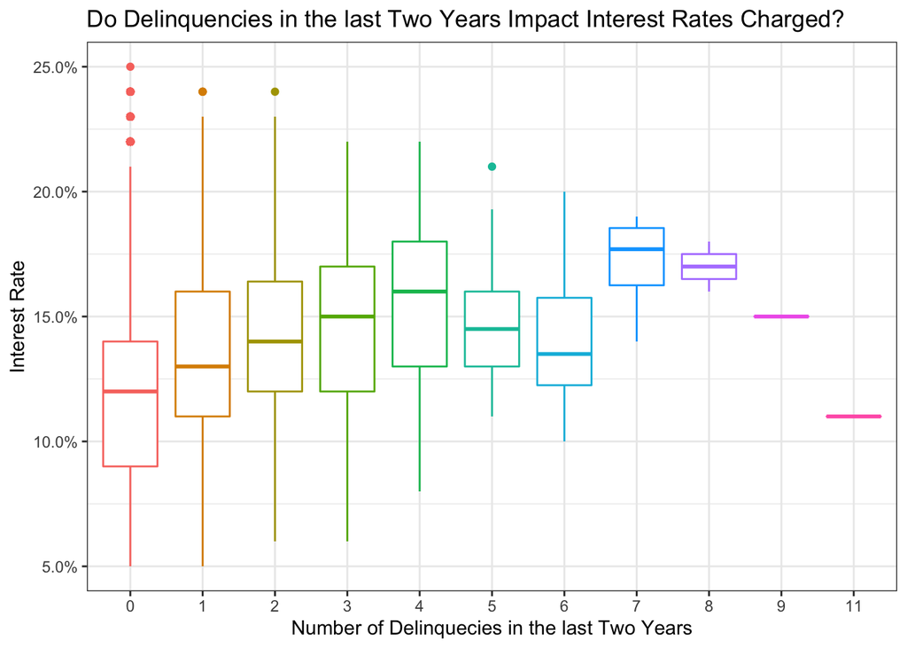

```r
# In the same axes, produce box plots of the interest rate for every value of delinquencies
ggplot(lc_clean , aes(y=int_rate, x=delinq_2yrs, colour= delinq_2yrs)) +
  geom_boxplot()+
  # geom_jitter()+
  theme_bw()+
   scale_y_continuous(labels=scales::percent)+
  theme(legend.position = "none")+
  labs(
    title = "Do Delinquencies in the last Two Years Impact Interest Rates Charged?",
    x= "Number of Delinquecies in the last Two Years", y="Interest Rate"
  )
```

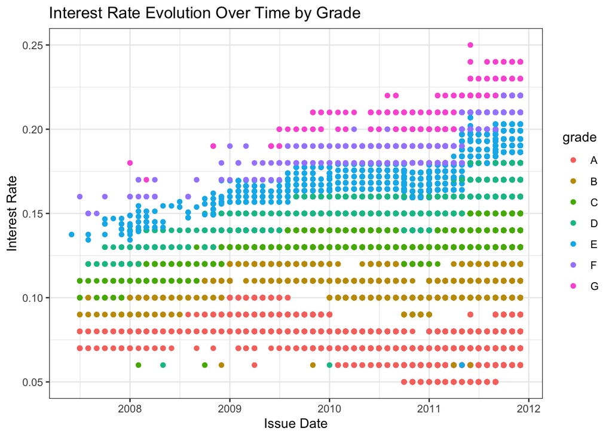

```r
ggplot(lc_clean, aes (y=int_rate, x=issue_d, color = grade))+
  geom_point()+
  theme_bw()+
  labs(title="Interest Rate Evolution Over Time by Grade", x="Issue Date", y="Interest Rate")
```

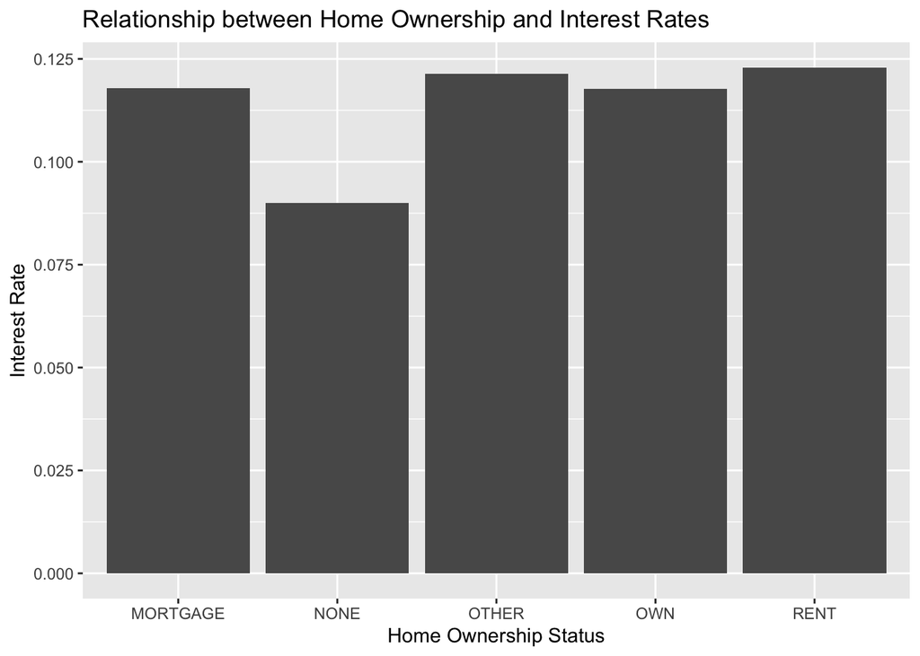

```r
lc_clean %>%
  group_by (home_ownership) %>%
  summarize (mean_int = mean(int_rate)) %>%
  ggplot (aes(x = home_ownership, y= mean_int))+geom_col()+
  labs (title = "Relationship between Home Ownership and Interest Rates", x="Home Ownership Status", y="Interest Rate")
```

# 3 Estimate simple linear regression models

We start with a simple but quite powerful model.

```r
# Use the lm command to estimate a regression model with the following variables "loan_amnt",  "term", "dti", "annual_inc", and "grade"

model1<-lm(int_rate ~ loan_amnt + term + dti + annual_inc + grade, data = lc_clean
  )
summary(model1)
```

```
##
## Call:
## lm(formula = int_rate ~ loan_amnt + term + dti + annual_inc +
##     grade, data = lc_clean)
##
## Residuals:
##       Min        1Q    Median        3Q       Max
## -0.118827 -0.007035 -0.000342  0.006828  0.035081
##
## Coefficients:
##               Estimate Std. Error t value Pr(>|t|)
## (Intercept)  7.169e-02  1.689e-04 424.363  < 2e-16 ***
## loan_amnt    1.475e-07  8.284e-09  17.809  < 2e-16 ***
## term60       3.608e-03  1.419e-04  25.431  < 2e-16 ***
## dti          4.328e-05  8.269e-06   5.234 1.66e-07 ***
## annual_inc  -9.734e-10  9.283e-10  -1.049    0.294
## gradeB       3.554e-02  1.492e-04 238.248  < 2e-16 ***
## gradeC       6.016e-02  1.658e-04 362.783  < 2e-16 ***
## gradeD       8.172e-02  1.906e-04 428.746  < 2e-16 ***
## gradeE       9.999e-02  2.483e-04 402.660  < 2e-16 ***
## gradeF       1.195e-01  3.673e-04 325.408  < 2e-16 ***
## gradeG       1.355e-01  6.208e-04 218.245  < 2e-16 ***
## ---
## Signif. codes:  0 '***' 0.001 '**' 0.01 '*' 0.05 '.' 0.1 ' ' 1
##
## Residual standard error: 0.01056 on 37858 degrees of freedom
## Multiple R-squared:  0.9198, Adjusted R-squared:  0.9197
## F-statistic: 4.34e+04 on 10 and 37858 DF,  p-value: < 2.2e-16
```

## 3.1 Q2 Analysis on model 1 (questions about model 1)

1. Are all variables statistically significant?
- All the values are statistically significant except for annual income. The P values for all variables are less than 0.05, but the P value for annual income is larder than 0.05.
2. Interpret all the coefficients in the regression.
- For all the coefficients in this equation, its interpretation is that if the loan amount increases by 100,000 the interest rate will increase by 1.5%.
- Additionally, if the loan term is 60 months, the interest rate of the loan will be higher than that of a 36 month loan by on average 0.36%. Futhermore, a one unit increase to the debt-to-income ratio will increase on average the loan interest rate by 0.0043%.
- Annual income is insignificant. Finally, comparing to Grade A, lowering the grade by each additional letter mean that the on average the interest rate will increase by 3.55% for Grabe B, 6.02% for Grade C, 8.17% for Grade D, 10% for Grade E, 12% for Grade F, and 14% for Grade G.
3. How much explanatory power does the model have?
- The model has an adjusted R squared of .9197. This means that the model can explain about 92% of the varibility of the interest rates with this data.
4. How wide would the 95% confidence interval of any prediction based on this model be?
- The confidence interval width is 4%, which is a high number when trying to predit interest rates.

# 4 Feature Engineering

Then we built progressively more complex models, with more features.

```r
#Add to model 1 an interaction between loan amount and grade. Use the "var1*var2" notation to define an interaction term in the linear regression model. This will add the interaction and the individual variables to the model.

model2 <- lm(int_rate ~ loan_amnt*grade + term +dti + annual_inc, data = lc_clean)
summary(model2)
```

```
##
## Call:
## lm(formula = int_rate ~ loan_amnt * grade + term + dti + annual_inc,
##     data = lc_clean)
##
## Residuals:
##       Min        1Q    Median        3Q       Max
## -0.119807 -0.007230 -0.000057  0.006588  0.037460
##
## Coefficients:
##                    Estimate Std. Error t value Pr(>|t|)
## (Intercept)       7.171e-02  2.345e-04 305.762  < 2e-16 ***
## loan_amnt         1.528e-07  2.028e-08   7.537 4.91e-14 ***
## gradeB            3.623e-02  2.732e-04 132.619  < 2e-16 ***
## gradeC            6.198e-02  2.988e-04 207.452  < 2e-16 ***
## gradeD            8.082e-02  3.483e-04 232.034  < 2e-16 ***
## gradeE            9.633e-02  4.625e-04 208.293  < 2e-16 ***
## gradeF            1.143e-01  7.735e-04 147.699  < 2e-16 ***
## gradeG            1.327e-01  1.551e-03  85.580  < 2e-16 ***
## term60            3.793e-03  1.424e-04  26.636  < 2e-16 ***
## dti               3.836e-05  8.250e-06   4.649 3.34e-06 ***
## annual_inc       -1.224e-09  9.249e-10  -1.324  0.18564
## loan_amnt:gradeB -6.617e-08  2.441e-08  -2.710  0.00673 **
## loan_amnt:gradeC -1.704e-07  2.621e-08  -6.500 8.14e-11 ***
## loan_amnt:gradeD  6.703e-08  2.798e-08   2.395  0.01662 *
## loan_amnt:gradeE  2.209e-07  3.016e-08   7.323 2.47e-13 ***
## loan_amnt:gradeF  2.779e-07  4.136e-08   6.720 1.85e-11 ***
## loan_amnt:gradeG  1.265e-07  7.260e-08   1.743  0.08140 .
## ---
## Signif. codes:  0 '***' 0.001 '**' 0.01 '*' 0.05 '.' 0.1 ' ' 1
##
## Residual standard error: 0.01052 on 37852 degrees of freedom
## Multiple R-squared:  0.9204, Adjusted R-squared:  0.9204
## F-statistic: 2.735e+04 on 16 and 37852 DF,  p-value: < 2.2e-16
```

```r
#Add to the model we just created above the square and the cube of annual income. Use the poly(var_name,3) command as a variable in the linear regression model.

model3 <-  lm(int_rate ~ loan_amnt*grade + term +dti + poly(annual_inc,3), data = lc_clean)
summary(model3)
```

```
##
## Call:
## lm(formula = int_rate ~ loan_amnt * grade + term + dti + poly(annual_inc,
##     3), data = lc_clean)
##
## Residuals:
##       Min        1Q    Median        3Q       Max
## -0.119814 -0.007238 -0.000065  0.006594  0.037471
##
## Coefficients:
##                        Estimate Std. Error t value Pr(>|t|)
## (Intercept)           7.161e-02  2.279e-04 314.200  < 2e-16 ***
## loan_amnt             1.556e-07  2.047e-08   7.600 3.03e-14 ***
## gradeB                3.623e-02  2.732e-04 132.611  < 2e-16 ***
## gradeC                6.198e-02  2.988e-04 207.398  < 2e-16 ***
## gradeD                8.081e-02  3.483e-04 231.999  < 2e-16 ***
## gradeE                9.633e-02  4.625e-04 208.283  < 2e-16 ***
## gradeF                1.143e-01  7.736e-04 147.695  < 2e-16 ***
## gradeG                1.327e-01  1.551e-03  85.573  < 2e-16 ***
## term60                3.786e-03  1.426e-04  26.546  < 2e-16 ***
## dti                   3.761e-05  8.294e-06   4.535 5.79e-06 ***
## poly(annual_inc, 3)1 -1.589e-02  1.117e-02  -1.423   0.1549
## poly(annual_inc, 3)2  6.296e-03  1.086e-02   0.580   0.5621
## poly(annual_inc, 3)3 -8.981e-03  1.084e-02  -0.828   0.4076
## loan_amnt:gradeB     -6.633e-08  2.442e-08  -2.717   0.0066 **
## loan_amnt:gradeC     -1.703e-07  2.621e-08  -6.498 8.23e-11 ***
## loan_amnt:gradeD      6.709e-08  2.798e-08   2.398   0.0165 *
## loan_amnt:gradeE      2.209e-07  3.016e-08   7.324 2.45e-13 ***
## loan_amnt:gradeF      2.780e-07  4.136e-08   6.722 1.82e-11 ***
## loan_amnt:gradeG      1.270e-07  7.260e-08   1.750   0.0801 .
## ---
## Signif. codes:  0 '***' 0.001 '**' 0.01 '*' 0.05 '.' 0.1 ' ' 1
##
## Residual standard error: 0.01052 on 37850 degrees of freedom
## Multiple R-squared:  0.9204, Adjusted R-squared:  0.9204
## F-statistic: 2.431e+04 on 18 and 37850 DF,  p-value: < 2.2e-16
```

```r
#Continuing with the previous model, instead of annual income as a continuous variable break it down into quartiles and use quartile dummy variables.

lc_clean <- lc_clean %>%
  mutate(quartiles_annual_inc = as.factor(ntile(annual_inc, 4)))

model4 <-lm(int_rate ~ loan_amnt*grade + term +dti + quartiles_annual_inc, data = lc_clean)
summary(model4)
```

```
##
## Call:
## lm(formula = int_rate ~ loan_amnt * grade + term + dti + quartiles_annual_inc,
##     data = lc_clean)
##
## Residuals:
##       Min        1Q    Median        3Q       Max
## -0.119767 -0.007203 -0.000064  0.006596  0.037581
##
## Coefficients:
##                         Estimate Std. Error t value Pr(>|t|)
## (Intercept)            7.187e-02  2.414e-04 297.700  < 2e-16 ***
## loan_amnt              1.615e-07  2.048e-08   7.889 3.13e-15 ***
## gradeB                 3.622e-02  2.733e-04 132.524  < 2e-16 ***
## gradeC                 6.196e-02  2.989e-04 207.272  < 2e-16 ***
## gradeD                 8.079e-02  3.484e-04 231.877  < 2e-16 ***
## gradeE                 9.632e-02  4.625e-04 208.273  < 2e-16 ***
## gradeF                 1.143e-01  7.735e-04 147.723  < 2e-16 ***
## gradeG                 1.327e-01  1.551e-03  85.570  < 2e-16 ***
## term60                 3.781e-03  1.425e-04  26.532  < 2e-16 ***
## dti                    3.672e-05  8.259e-06   4.446 8.78e-06 ***
## quartiles_annual_inc2 -2.619e-04  1.548e-04  -1.692  0.09068 .
## quartiles_annual_inc3 -3.992e-04  1.590e-04  -2.510  0.01208 *
## quartiles_annual_inc4 -5.382e-04  1.692e-04  -3.181  0.00147 **
## loan_amnt:gradeB      -6.638e-08  2.441e-08  -2.719  0.00655 **
## loan_amnt:gradeC      -1.699e-07  2.621e-08  -6.483 9.10e-11 ***
## loan_amnt:gradeD       6.770e-08  2.798e-08   2.419  0.01555 *
## loan_amnt:gradeE       2.203e-07  3.016e-08   7.304 2.85e-13 ***
## loan_amnt:gradeF       2.766e-07  4.136e-08   6.687 2.30e-11 ***
## loan_amnt:gradeG       1.267e-07  7.259e-08   1.746  0.08089 .
## ---
## Signif. codes:  0 '***' 0.001 '**' 0.01 '*' 0.05 '.' 0.1 ' ' 1
##
## Residual standard error: 0.01052 on 37850 degrees of freedom
## Multiple R-squared:  0.9204, Adjusted R-squared:  0.9204
## F-statistic: 2.432e+04 on 18 and 37850 DF,  p-value: < 2.2e-16
```

```r
#Compare the performance of these four models using the anova command
anova(model1, model2, model3, model4)
```

| Res.Df | RSS | Df | Sum of Sq | F | Pr(>F) |
| --- | --- | --- | --- | --- | --- |
| 3.79e+04 | 4.22 |  |  |  |  |
| 3.79e+04 | 4.19 | 6 | 0.0332 | 50 | 1.64e-61 |
| 3.78e+04 | 4.19 | 2 | 0.000107 | 0.484 | 0.616 |
| 3.78e+04 | 4.19 | 0 | 0.000915 |  |  |